# Data Science II Homework 3

Arghya Kannadaguli (ak5357)

2025-03-31

```r
library(tidyverse)
library(ggplot2)
library(dplyr)
library(caret)
library(rsample)
library(car)
library(earth)
library(pROC)
```

In this problem, you will develop a model to predict whether a given car gets high or low gas mileage based on the dataset “auto.csv”. The dataset contains 392 observations. The response variable is “mpg cat”, which indicates whether the miles per gallon of a car is high or low. The predictors include both continuous and categorical variables:

- cylinders: Number of cylinders between 4 and 8
- displacement: Engine displacement (cu. inches)
- horsepower: Engine horsepower
- weight: Vehicle weight (lbs.)
- acceleration: Time to accelerate from 0 to 60 mph (sec.)
- year: Model year (modulo 100)
- origin: Origin of car (1. American, 2. European, 3. Japanese)

**Split the dataset into two parts: training data (70%) and test data (30%).**

```r
auto = read_csv("data/auto.csv")

set.seed(2025)

# Split Data
data_split = initial_split(auto, prop = 0.7)
training_data = training(data_split)
testing_data = testing(data_split)

# Cross Validation Setup
ctrl1 = trainControl(method = "cv",
                     number = 10,
                     classProbs = TRUE,
                     summaryFunction = twoClassSummary)
```

**(a) Perform logistic regression analysis. Are there redundant predictors in your model? If so, identify them. If there are none, please provide an explanation.**

Train model.

```r
set.seed(2025)

log_model = train(
  mpg_cat ~ .,
  data = training_data,
  method = "glm",
  family = "binomial",
  trControl = ctrl1,
  metric = "ROC"
)

summary(log_model$finalModel)
```

```
##
## Call:
## NULL
##
## Coefficients:
##               Estimate Std. Error z value Pr(>|z|)
## (Intercept)  14.614529   6.885006   2.123 0.033782 *
## cylinders     0.609820   0.529842   1.151 0.249754
## displacement -0.008675   0.014204  -0.611 0.541403
## horsepower    0.017059   0.027805   0.614 0.539539
## weight        0.005076   0.001423   3.567 0.000361 ***
## acceleration -0.080766   0.172089  -0.469 0.638834
## year         -0.398303   0.087738  -4.540 5.63e-06 ***
## origin       -0.373142   0.444743  -0.839 0.401467
## ---
## Signif. codes:  0 '***' 0.001 '**' 0.01 '*' 0.05 '.' 0.1 ' ' 1
##
## (Dispersion parameter for binomial family taken to be 1)
##
##     Null deviance: 379.61  on 273  degrees of freedom
## Residual deviance: 110.24  on 266  degrees of freedom
## AIC: 126.24
##
## Number of Fisher Scoring iterations: 8
```

Check for redundant predictors. Based on this, it appears there may be some redundant predictors. The variables cylinders and weight have moderate but likely acceptable correlation, since their VIF outputs are below 5. The variables horsepower, acceleration, year, and origin also have no multicollinearity issue, since their VIF outputs are even lower. However, the displacement variable does have a potential multicollinearity issue, since its VIF output is over 5.

```r
vif(log_model$finalModel)
```

```
##    cylinders displacement   horsepower       weight acceleration         year
##     4.965330     8.372139     2.577474     4.681329     2.853893     1.726715
##       origin
##     1.991936
```

```r
glmnGrid = expand.grid(.alpha = seq(0, 1, length = 21),
                        .lambda = exp(seq(-8, -1, length = 50)))

glmn_model = train(x = training_data[1:7],
                   y = training_data$mpg_cat,
                   method = "glmnet",
                   tuneGrid = glmnGrid,
                   metric = "ROC",
                   trControl = ctrl1)

glmn_model$bestTune
```

```
##      alpha     lambda
## 1031     1 0.02437284
```

```r
coef(glmn_model$finalModel, s = glmn_model$bestTune$lambda)
```

```
## 8 x 1 sparse Matrix of class "dgCMatrix"
##                       s1
## (Intercept)   4.59188069
## cylinders     0.47077987
## displacement  .
## horsepower    .
## weight        0.00248297
## acceleration  .
## year         -0.18623287
## origin        .
```

Visualize training.

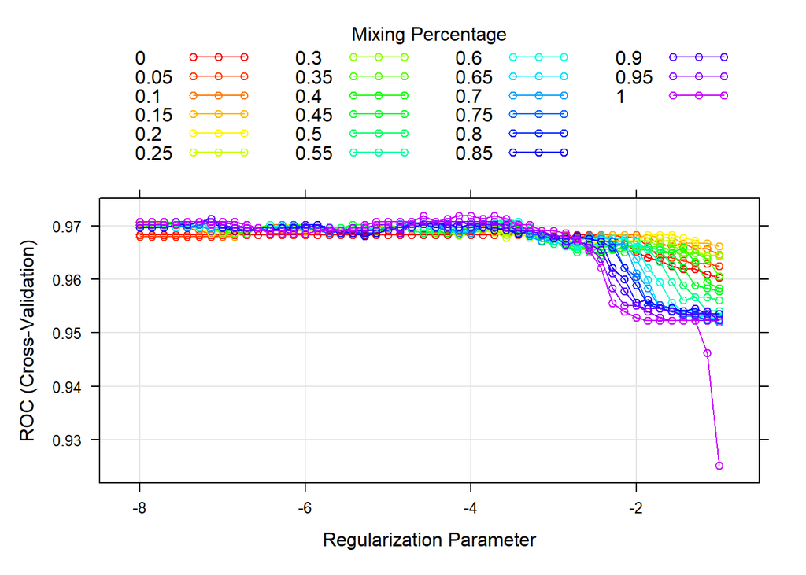

```r
myCol = rainbow(25)
myPar = list(superpose.symbol = list(col = myCol),
             superpose.line = list(col = myCol))
plot(glmn_model, par.settings = myPar, xTrans = function(x) log(x))
```

**(b) Train a multivariate adaptive regression spline (MARS) model. Does the MARS model improve prediction performance compared to logistic regression?**

```r
set.seed(2025)
mars_grid = expand.grid(degree = 1:4, nprune = 2:20)
mars_model = train(x = training_data[1:7],
                 y = training_data$mpg_cat,
                 method = "earth",
                 tuneGrid = mars_grid,
                 trControl = ctrl1,
                 metric = "ROC")

summary(mars_model)
```

```
## Call: earth(x=tbl_df[274,7], y=factor.object, keepxy=TRUE,
##             glm=list(family=function.object, maxit=100), degree=1, nprune=7)
##
## GLM coefficients
##                            low
## (Intercept)         -39.296303
## h(cylinders-4)       20.317608
## h(6-cylinders)       18.608891
## h(cylinders-6)      -19.799605
## h(displacement-232)  -0.054199
## h(weight-2228)        0.006122
## h(year-72)           -0.674781
##
## GLM (family binomial, link logit):
##  nulldev  df       dev  df   devratio     AIC iters converged
##  379.611 273   81.5987 267      0.785    95.6    15         1
##
## Earth selected 7 of 15 terms, and 4 of 7 predictors (nprune=7)
## Termination condition: Reached nk 21
## Importance: cylinders, year, displacement, weight, horsepower-unused, ...
## Number of terms at each degree of interaction: 1 6 (additive model)
## Earth GCV 0.06519687    RSS 16.20904    GRSq 0.7408917    RSq 0.7631698
```

Optimal tuning parameters.

```r
mars_model$bestTune
```

```
##   nprune degree
## 6      7      1
```

Optimal model.

```r
coef(mars_model$finalModel)
```

```
##         (Intercept) h(displacement-232)      h(weight-2228)      h(cylinders-6)
##       -39.296303427        -0.054198739         0.006122005       -19.799604924
##      h(6-cylinders)          h(year-72)      h(cylinders-4)
##        18.608890665        -0.674780568        20.317607660
```

Visualize.

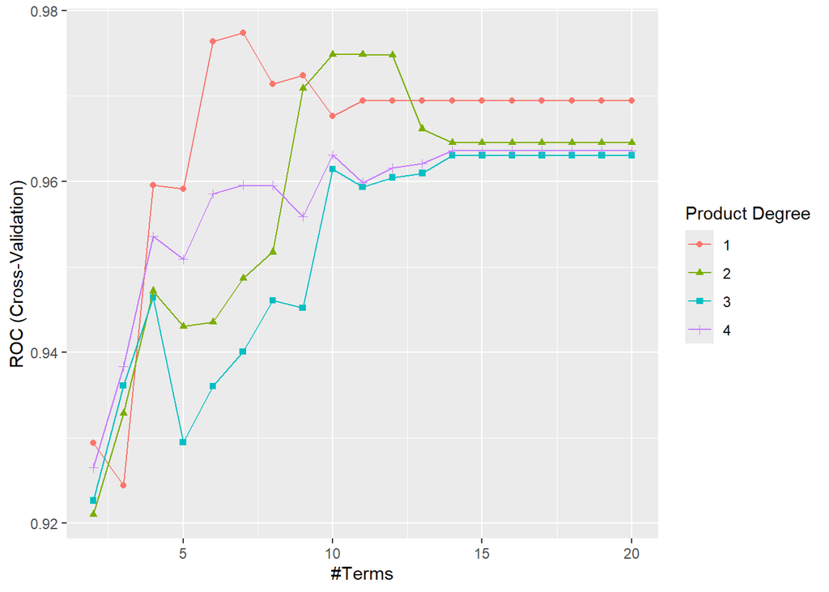

```r
ggplot(mars_model)
```

Compare models. Based on the results below, it looks like the MARS model has the highest mean and median ROC, indicating that it has the best ability to discriminate between “high” and “low” mpg_cat.

```r
resamp = resamples(list(MARS = mars_model,
                        LOG = log_model,
                        GLMNET = glmn_model))
summary(resamp)
```

```
##
## Call:
## summary.resamples(object = resamp)
##
## Models: MARS, LOG, GLMNET
## Number of resamples: 10
##
## ROC
##             Min.   1st Qu.    Median      Mean   3rd Qu.      Max. NA's
## MARS   0.9438776 0.9616954 0.9793956 0.9773783 0.9931319 1.0000000    0
## LOG    0.9183673 0.9430926 0.9576138 0.9628414 0.9890110 1.0000000    0
## GLMNET 0.9505495 0.9532967 0.9762559 0.9718498 0.9876374 0.9904762    0
##
## Sens
##             Min.   1st Qu.    Median      Mean 3rd Qu. Max. NA's
## MARS   0.8571429 0.9285714 0.9666667 0.9504762       1    1    0
## LOG    0.8571429 0.8821429 0.9285714 0.9366667       1    1    0
## GLMNET 0.8571429 0.9464286 1.0000000 0.9714286       1    1    0
##
## Spec
##             Min.   1st Qu.    Median      Mean   3rd Qu. Max. NA's
## MARS   0.6923077 0.8571429 0.9230769 0.9027473 0.9821429    1    0
## LOG    0.7142857 0.8008242 0.9230769 0.8890110 0.9821429    1    0
## GLMNET 0.7692308 0.8489011 0.9230769 0.8939560 0.9230769    1    0
```

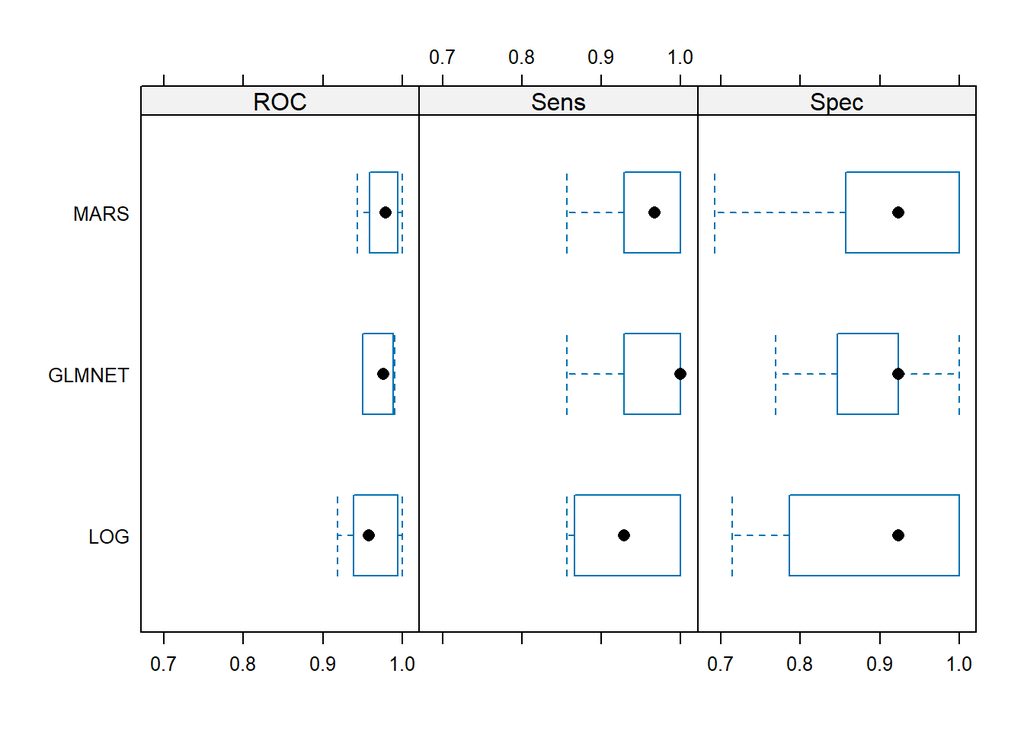

```r
bwplot(resamp)
```

**(c) Perform linear discriminant analysis using the training data. Plot the linear discriminant(s).**

Train LDA model.

```r
set.seed(2025)
lda_model = train(x = training_data[1:7],
                 y = training_data$mpg_cat,
                 method = "lda",
                 trControl = ctrl1,
                 metric = "ROC")

lda_model$finalModel
```

```
## Call:
## lda(x, y)
##
## Prior probabilities of groups:
##      high       low
## 0.5145985 0.4854015
##
## Group means:
##      cylinders displacement horsepower   weight acceleration     year   origin
## high  4.177305     117.2234   79.64539 2356.418     16.54184 77.56738 1.914894
## low   6.819549     277.1053  131.87970 3671.331     14.55113 74.48872 1.172932
##
## Coefficients of linear discriminants:
##                       LD1
## cylinders     0.629528330
## displacement -0.002526146
## horsepower   -0.013003509
## weight        0.001338339
## acceleration -0.005930811
## year         -0.111523778
## origin       -0.110273650
```

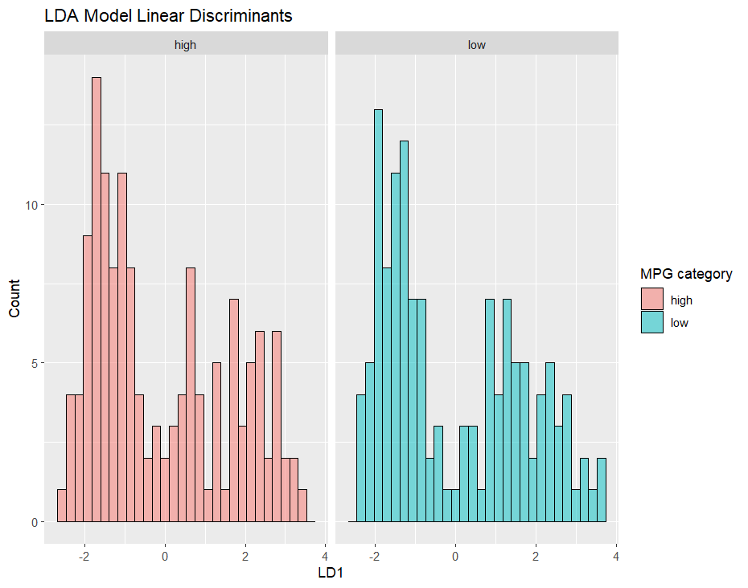

```r
# extract final LDA model
lda_final_model = lda_model$finalModel

# get linear discriminants
lda_scores = predict(lda_final_model)$x

# add true class labels to scores for coloring in later plot
lda_scores = data.frame(lda_scores, mpg_cat = training_data$mpg_cat)

# plot first two linear discriminants (LD1 and LD2)
ggplot(lda_scores, aes(x = LD1, fill = mpg_cat)) +
  geom_histogram(position = "dodge", color = "black", lwd = 0.5, alpha = 0.5) +
  labs(title = "LDA Model Linear Discriminants",
       x = "LD1",
       y = "Count",
       fill = "MPG category") +
  facet_grid(~ mpg_cat)
```

**(d) Which model will you choose to predict the response variable? Plot its ROC curve and report the AUC. Next, select a probability threshold to classify observations and compute the confusion matrix. Briefly interpret what the confusion matrix indicates about your model’s performance.**

Compare models again. Based on the results below, it looks like the MARS model still has the highest mean and median ROC, indicating that it has the best ability to discriminate between “high” and “low” mpg_cat.

```r
resamp = resamples(list(MARS = mars_model,
                        LOG = log_model,
                        GLMNET = glmn_model,
                        LDA = lda_model))
summary(resamp)
```

```
##
## Call:
## summary.resamples(object = resamp)
##
## Models: MARS, LOG, GLMNET, LDA
## Number of resamples: 10
##
## ROC
##             Min.   1st Qu.    Median      Mean   3rd Qu.      Max. NA's
## MARS   0.9438776 0.9616954 0.9793956 0.9773783 0.9931319 1.0000000    0
## LOG    0.9183673 0.9430926 0.9576138 0.9628414 0.9890110 1.0000000    0
## GLMNET 0.9505495 0.9532967 0.9762559 0.9718498 0.9876374 0.9904762    0
## LDA    0.8724490 0.9120879 0.9733124 0.9522240 0.9876374 1.0000000    0
##
## Sens
##             Min.   1st Qu.    Median      Mean 3rd Qu. Max. NA's
## MARS   0.8571429 0.9285714 0.9666667 0.9504762       1    1    0
## LOG    0.8571429 0.8821429 0.9285714 0.9366667       1    1    0
## GLMNET 0.8571429 0.9464286 1.0000000 0.9714286       1    1    0
## LDA    0.9285714 0.9500000 1.0000000 0.9790476       1    1    0
##
## Spec
##             Min.   1st Qu.    Median      Mean   3rd Qu. Max. NA's
## MARS   0.6923077 0.8571429 0.9230769 0.9027473 0.9821429    1    0
## LOG    0.7142857 0.8008242 0.9230769 0.8890110 0.9821429    1    0
## GLMNET 0.7692308 0.8489011 0.9230769 0.8939560 0.9230769    1    0
## LDA    0.6153846 0.8461538 0.8901099 0.8582418 0.9271978    1    0
```

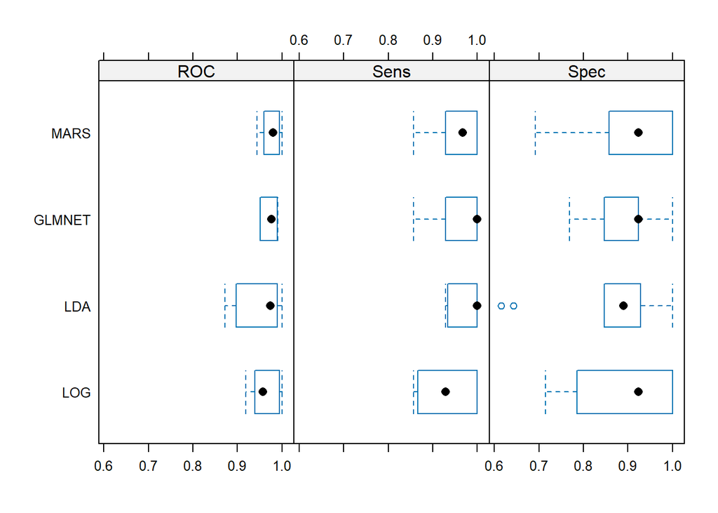

```r
bwplot(resamp)
```

MARS model ROC curve.

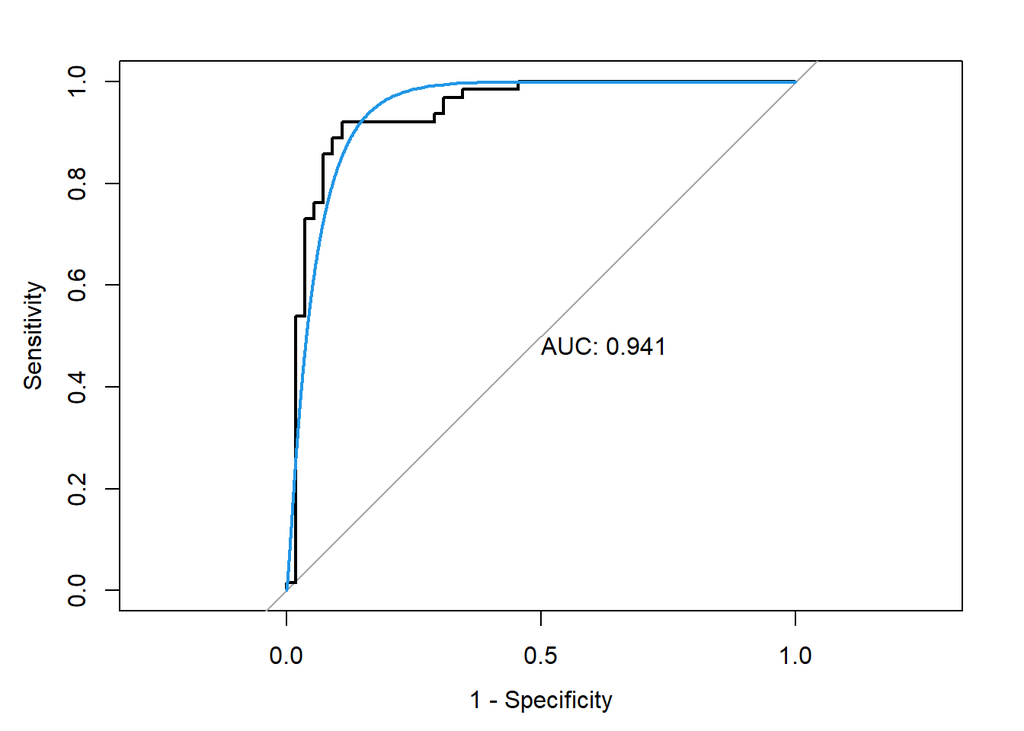

```r
# predict probabilities on test data using MARS model
mars_pred_prob = predict(mars_model, newdata = testing_data, type = "prob")

# positive class is "high" mpg
test_pred_prob = mars_pred_prob$high

# Generate ROC curve
roc_mars = roc(testing_data$mpg_cat, test_pred_prob)

# =lot ROC curve and smoothed ROC curve
plot(roc_mars, legacy.axes = TRUE, print.auc = TRUE)
plot(smooth(roc_mars), col = 4, add = TRUE)
```

Generate confusion matrix.

```r
# set threshold and classify observations
threshold = 0.5
test_pred = ifelse(test_pred_prob > threshold, "high", "low")

# compute confusion matrix
conf_matrix = confusionMatrix(data = as.factor(test_pred),
                reference = as.factor(testing_data$mpg_cat),
                positive = "high")

conf_matrix
```

```
## Confusion Matrix and Statistics
##
##           Reference
## Prediction high low
##       high   49   7
##       low     6  56
##
##                Accuracy : 0.8898
##                  95% CI : (0.819, 0.94)
##     No Information Rate : 0.5339
##     P-Value [Acc > NIR] : <2e-16
##
##                   Kappa : 0.7789
##
##  Mcnemar's Test P-Value : 1
##
##             Sensitivity : 0.8909
##             Specificity : 0.8889
##          Pos Pred Value : 0.8750
##          Neg Pred Value : 0.9032
##              Prevalence : 0.4661
##          Detection Rate : 0.4153
##    Detection Prevalence : 0.4746
##       Balanced Accuracy : 0.8899
##
##        'Positive' Class : high
##
```

Based on this confusion matrix, we can see that when applied to the test data, the MARS model correctly predicted 49 true positives and 56 true negatives, compared to 7 false positives and 6 false negatives.

The overall accuracy of the model, based on assessment using the testing data, is 88.98%, which is the proportion of predictions that were made correctly. The 95% confidence interval tells us that we are 95% confident that the true accuracy is between 81.9% and 94%.

The no information rate of 0.5339 tells us the accuracy that the model would have if it were to always predict only the most frequent class. When compared with the accuracy, this shows us that the MARS model performs better than random guessing.

Finally, the p-value is very small, telling us that the model is significantly better than a randomly guessing model.